# Introduction to *clusso*

# Introduction

Please report any issues [here](https://github.com/mkamenet3/clusso/issues).

Load the `clusso` library:

```r
library("clusso")
```

If you haven't already, you can install `clusso` directly from GitHub:

```r
library("devtools")
devtools::install_github("mkamenet3/clusso")
```

## Using `clusso`

In this example, we will use simulated data of breast cancer incidence counts across 208 prefects (municipalities) in Japan across 5 time periods. These data are based on original incidence counts, but we have added noise to these data.

### Prepare Data

```r
#load data
data("jbc")
data("utmJapan")
```

1. `utmJapan`: data set containing a unique identifier for each prefect centroid (*id*), x-coordinate in UTM (*utmx*), and y-coordinate in UTM (*utmy*).
2. `jbc`: data set containing a unique identifier for each centroid (*id*), period of observation (categorical variable with 5 levels, *period*), death count (*death*), expected death count (*expdeath*). These data are simulated (with some noise) based on observed data.

```r
#inspect
head(utmJapan)
```

```
##     id     utmx    utmy
## 1 9201 399786.6 4047756
## 2 9202 360917.0 4023885
## 3 9203 385175.1 4025749
## 4 9204 371603.4 4018172
## 5 9205 388154.2 4047900
## 6 9206 375023.3 4068053
```

```r
head(jbc)
```

```
##     id period death expdeath   covar1     covar2 covar3 covar4 covar5
## 1 9201   7906    35 36.75088 458.5877 0.01894360     34      1      0
## 2 9201   7922    53 41.78682 470.2921 0.08078908     40      1      0
## 3 9201   7938    41 47.41040 490.6435 0.02267590     32      0      1
## 4 9201   7954    66 53.36025 501.6789 0.03259346     35      0      0
## 5 9201   7970    73 58.70772 531.8578 0.01600942     32      0      1
## 6 9202   7906    15 19.77900 521.2707 0.05811436     31      0      0
```

We first convert `period` to a factor in the data frame `jbc`:

```r
jbc$period <- as.factor(jbc$period)
```

### Set global parameters

When using `clusso`, there are global parameters that need to be set first.

We take the easting and northing coordinates from the `utmJapan` data set, set the easting coordinate, `utmx`, to `x` and the northing coordinate, `utmy`, to `y`. Each is divided by 1000 to change the scale from meters to kilometers.

```r
x <- utmJapan$utmx/1000
y <- utmJapan$utmy/1000
```

Below, we set the maximum radius for a cluster to 20 km (`rMax=20`) based on scientific knowledge of the area and our definition of a meaningful cluster. We set the number of unique time periods to 5 (`Time=5`), and set a floor for overdispersion to avoid estimating underdispersion (`overdispfloor=TRUE`).

```r
rMax <- 20
Time <- 5
overdispfloor <- TRUE
```

If you do not have expected counts readily available, they can be calculated using the auxiliary function `calcexpected()`, from the `clusso` package.

As an example, we generate some data and apply `calcexpected()`. The output is a dataframe with an additional variable, `expected`, which contains the expected counts:

```r
set.seed(2)
period <- rep(c("1","2"), times=5)
observed <- MASS::rnegbin(n = length(period), mu=20, theta=2)
pop <-  MASS::rnegbin(n = length(period), mu=200, theta=2)
ids <- rep(1:5, each=2)

calcexpected(observed, pop, period, ids)
```

```
##    ids periods population observed  expected
## 1    1       1        298        5 19.288026
## 2    1       2        112       10  7.249191
## 3    2       1        455        2 29.449838
## 4    2       2         67        7  4.336570
## 5    3       1         87       11  5.631068
## 6    3       2         50       12  3.236246
## 7    4       1        314       10 20.323625
## 8    4       2        165       17 10.679612
## 9    5       1        207       40 13.398058
## 10   5       2         99        6  6.407767
```

In this data example, we already have expected counts and will use the dataframe `jbc`.

### Fitting using `clusso`

To perform the regularized spatial and spatio-temporal cluster detection using the Lasso penalty, we use the function `clusso()`. In the first argument, we set the name of the dataframe, `df=jbc`. In the second argument we set the expected counts equal to the name of expected counts in the `jbc` dataframe (`expected = expdeath`). In the third argument, we set the observed counts equal to the name of the observed counts in the `jbc` dataframe (`observed = death`). In the fourth argument, we set the time period equal to the name of the time periods in the `jbc` dataframe (`timeperiod = period`). This variable has already been converted to a factor in the data-cleaning step above (`jbc$period <- as.factor(jbc$period)`). In this example, we do not want to include other covariates as unpenalized terms in the model so we set `covars = FALSE`.

The next two arguments are `x` and `y`, which are the UTM easting and northing coordinates, scaled to be in kilometers. The next argument is the maximum radius (in km) for the potential clusters. We set `rMax = rMax`, which we defined above as 20km. The argument `utm` specifies that our coordinates are indeed in UTM coordinates (`utm = TRUE`). For latitude-longitude coordinates, we would set `utm = FALSE`. The is `analysis` argument defines the type of analysis to be performed. Options include `space`, `spacetime`, or `both`. Here, we set `analysis` equal to "both", which will perform both the spatial and spatio-temporal analyses. The argument `model` is the type of model to be used. Currently (2020-09-14), either the Poisson or binomial models can be specified. In this example, we specify the Poisson model. The final required argument is `maxclust`. This is the maximum number of actual clusters expected in the given area. This is based on scientific knowledge of the area. For the Japanese breast cancer data, we set `maxclust=11`. If the number of identified clusters exceeds `maxclust`, a warning will encourage you to increase your set `maxclust`.

The output of `clusso()` is assigned to the object `resreal`. `resreal` is a large list of lists. The recommended way to explore the results is to explore the `names(resreal)` and select each sub-list of interest.

```r
head(jbc)
```

```
##     id period death expdeath   covar1     covar2 covar3 covar4 covar5
## 1 9201   7906    35 36.75088 458.5877 0.01894360     34      1      0
## 2 9201   7922    53 41.78682 470.2921 0.08078908     40      1      0
## 3 9201   7938    41 47.41040 490.6435 0.02267590     32      0      1
## 4 9201   7954    66 53.36025 501.6789 0.03259346     35      0      0
## 5 9201   7970    73 58.70772 531.8578 0.01600942     32      0      1
## 6 9202   7906    15 19.77900 521.2707 0.05811436     31      0      0
```

```r
system.time(resreal <- clusso(jbc, expected = expdeath, observed=death,timeperiod = period,
                              covars=FALSE, id = id, x= x,y = y, rMax =  rMax,
                              utm=TRUE, analysis="both", model="poisson",maxclust=11))
```

```
## Running Poisson both spatial and spatio-temporal model(s).
```

```
## Creating radius-based potential clusters
```

```
## No covariates found
```

```
## Number of potential clusters to scan through:  66870
```

```
## Path selection: information criteria
```

```
## Lasso complete - extracting estimates and paths
```

```
## Overdispersion estimate: 2.1011
```

```
## No covariates found
```

```
## Number of potential clusters to scan through:  66870
```

```
## Path selection: information criteria
```

```
## Lasso complete - extracting estimates and paths
```

```
## No covariates found
```

```
## Number of potential clusters to scan through:  66870
```

```
## Path selection: information criteria
```

```
## Lasso complete - extracting estimates and paths
```

```
## Overdispersion estimate: 2.1011
```

```
## No covariates found
```

```
## Number of potential clusters to scan through:  66870
```

```
## Path selection: information criteria
```

```
## Lasso complete - extracting estimates and paths
```

```
## All models ran successfully
```

```
##    user  system elapsed
##   25.36    0.34   28.33
```

We can use the function `clussopretty()` to create a nice table for the number of clusters detected:

```r
clussopretty(resreal, analysis="both", model="poisson",clusteridentify=FALSE)
```

```
##           model analysistype numclust.AIC numclust.AICc numclust.BIC
## 1       Poisson        Space            8             8            4
## 2       Poisson   Space-Time            8             8            4
## 3 Quasi-Poisson        Space            4             4            3
## 4 Quasi-Poisson   Space-Time            4             4            3
```

With the argument `clusteridentify=TRUE`, centroid indices (by time period) are extracted. Since these lists are very long, output is left to the user to explore:

```r
#identify cluster IDs
clussopretty(resreal, analysis="both", model="poisson",clusteridentify=TRUE)
#identify cluster IDs where RR is greater or equal to 1.05
clussopretty(resreal, analysis="both", model="poisson", clusteridentify=TRUE, clusterRR = 1.05)
#identify cluster IDS that differ from the background rate
clussopretty(resreal, analysis="both", model="poisson", clusteridentify=TRUE, clusterRR = "background")
```

We can plot the output using `clussoplot()` to visualize the coefficient paths, where each line is the path for a potential cluster and the final selected clusters are identified with dashed vertical lines:

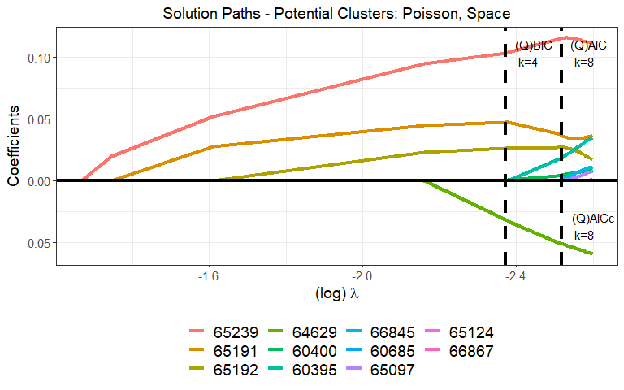

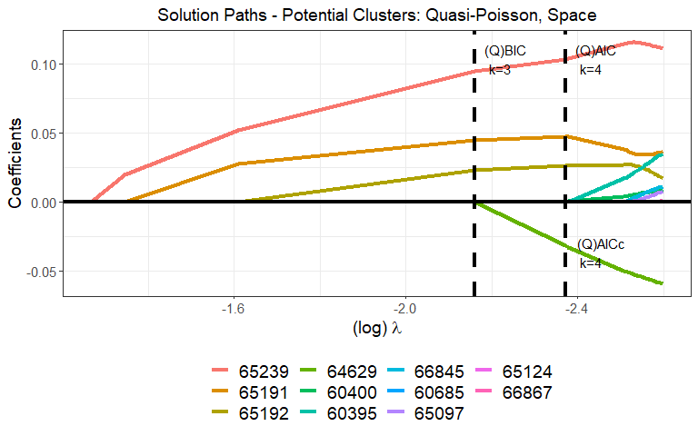

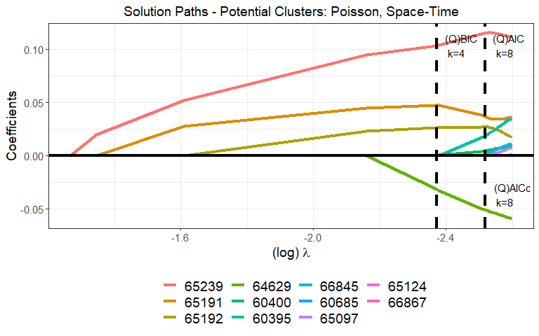

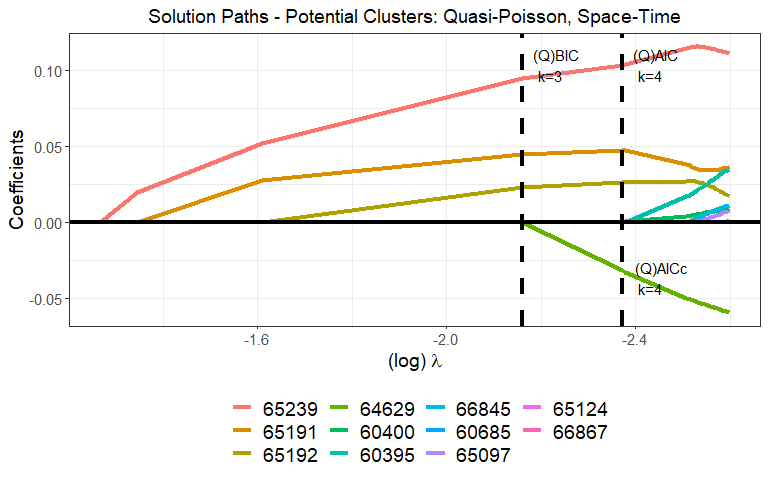

```r
clussoplot(resreal, analysis="both",model="poisson", Time=5, cv=FALSE)
```

## Comparison to Cross-Validation

We continue with the same data set as above, but now explore results by $k$-fold cross-validation. All initial inputs are assumed to be the same. We specify a total of 5 folds using the argument `cv=5` in the `clusso()` function.

```r
#perform clusso using cv (5 folds)
system.time(rescv <- clusso(jbc, expected = expdeath, observed=death,timeperiod = period,
                            id=id, covars=FALSE, x= x,y = y, rMax =  rMax, utm=TRUE,
                            analysis="both", model="poisson",maxclust=11, cv=5))
```

```
## Running cross-validation method for path selection. For AIC, AICc, and BIC, set `cv = NULL`
```

```
## Running Poisson both spatial and spatio-temporal model(s).
```

```
## Creating radius-based potential clusters
```

```
## No covariates found
```

```
## Number of potential clusters to scan through:  66870
```

```
## Path selection: cross-validation
```

```
## No covariates found
```

```
## Number of potential clusters to scan through:  66870
```

```
## Path selection: cross-validation
```

```
## No covariates found
```

```
## Number of potential clusters to scan through:  66870
```

```
## Path selection: cross-validation
```

```
## No covariates found
```

```
## Number of potential clusters to scan through:  66870
```

```
## Path selection: cross-validation
```

```
## All models ran successfully
```

```
##    user  system elapsed
##   80.56    0.86   82.15
```

```r
clussopretty(rescv, analysis="both", model="poisson",clusteridentify=FALSE, cv=TRUE)
```

```
##           model analysistype numclust.cv
## 1       Poisson        Space           7
## 2       Poisson   Space-Time          13
## 3 Quasi-Poisson        Space           7
## 4 Quasi-Poisson   Space-Time          13
```

## Example with Covariates

We continue with the Japanese breast cancer data set imported above, but now consider covariates in the model that will be unpenalized.

We explore the first 6 observations of the `jbc` dataframe using the `head()` function.

```r
#Set-up
head(jbc)
```

```
##     id period death expdeath   covar1     covar2 covar3 covar4 covar5
## 1 9201   7906    35 36.75088 458.5877 0.01894360     34      1      0
## 2 9201   7922    53 41.78682 470.2921 0.08078908     40      1      0
## 3 9201   7938    41 47.41040 490.6435 0.02267590     32      0      1
## 4 9201   7954    66 53.36025 501.6789 0.03259346     35      0      0
## 5 9201   7970    73 58.70772 531.8578 0.01600942     32      0      1
## 6 9202   7906    15 19.77900 521.2707 0.05811436     31      0      0
```

There are 5 additional covariates, `covar1` - `covar5` that we will want to adjust for in our Poisson or quasi-Poisson regression as unpenalized terms.

We now set the argument `covars=TRUE` to tell `clusso()` to identify the covariates and to include them as unpenalized terms:

```r
system.time(rescovars<- clusso(df=jbc, expected = expdeath, observed=death,
                               timeperiod = period, id=id, covars=TRUE,
                               x= x,y = y, rMax =  rMax, utm=TRUE, analysis="both",
                               model="poisson",maxclust=11,overdispfloor = TRUE,
                               cv=NULL, collapsetime = FALSE))
```

```
## Running Poisson both spatial and spatio-temporal model(s).
```

```
## Creating radius-based potential clusters
```

```
## Running with covariates
```

```
## Number of potential clusters to scan through:  66870
```

```
## Path selection: information criteria
```

```
## Lasso complete - extracting estimates and paths
```

```
## Overdispersion estimate: 2.0996
```

```
## Running with covariates
```

```
## Number of potential clusters to scan through:  66870
```

```
## Path selection: information criteria
```

```
## Lasso complete - extracting estimates and paths
```

```
## Running with covariates
```

```
## Number of potential clusters to scan through:  66870
```

```
## Path selection: information criteria
```

```
## Lasso complete - extracting estimates and paths
```

```
## Overdispersion estimate: 2.0996
```

```
## Running with covariates
```

```
## Number of potential clusters to scan through:  66870
```

```
## Path selection: information criteria
```

```
## Lasso complete - extracting estimates and paths
```

```
## All models ran successfully
```

```
##    user  system elapsed
##   22.63    0.28   22.97
```

Use `clussopretty()` to create a nice table of clusters detected:

```r
clussopretty(rescovars, analysis="both", model="poisson",clusteridentify = FALSE)
```

```
##           model analysistype numclust.AIC numclust.AICc numclust.BIC
## 1       Poisson        Space            7             7            3
## 2       Poisson   Space-Time            7             7            3
## 3 Quasi-Poisson        Space            7             7            3
## 4 Quasi-Poisson   Space-Time            7             7            3
```

We can also extract the coefficients for the unpenalized terms and undo the log-link by exponentiating:

```r
out <- clussopretty(rescovars, analysis="both", model="poisson",covars=TRUE)
out$table.coefs
```

```
##         IC         model analysistype time_period1 time_period2 time_period3
## 1   (Q)AIC       Poisson        Space            0            0            0
## 2   (Q)AIC       Poisson   Space-Time            0            0            0
## 3   (Q)AIC       Poisson        Space            0            0            0
## 4   (Q)AIC       Poisson   Space-Time            0            0            0
## 5  (Q)AICc Quasi-Poisson        Space            0            0            0
## 6  (Q)AICc Quasi-Poisson   Space-Time            0            0            0
## 7  (Q)AICc Quasi-Poisson        Space            0            0            0
## 8  (Q)AICc Quasi-Poisson   Space-Time            0            0            0
## 9   (Q)BIC       Poisson        Space            0            0            0
## 10  (Q)BIC       Poisson   Space-Time            0            0            0
## 11  (Q)BIC       Poisson        Space            0            0            0
## 12  (Q)BIC       Poisson   Space-Time            0            0            0
## 13  (Q)AIC Quasi-Poisson        Space            0            0            0
## 14  (Q)AIC Quasi-Poisson   Space-Time            0            0            0
```

[output cut: 60 more lines]

```r
out$table.expcoefs
```

```
##         IC         model analysistype time_period1 time_period2 time_period3
## 1   (Q)AIC       Poisson        Space            1            1            1
## 2   (Q)AIC       Poisson   Space-Time            1            1            1
## 3   (Q)AIC       Poisson        Space            1            1            1
## 4   (Q)AIC       Poisson   Space-Time            1            1            1
## 5  (Q)AICc Quasi-Poisson        Space            1            1            1
## 6  (Q)AICc Quasi-Poisson   Space-Time            1            1            1
## 7  (Q)AICc Quasi-Poisson        Space            1            1            1
## 8  (Q)AICc Quasi-Poisson   Space-Time            1            1            1
## 9   (Q)BIC       Poisson        Space            1            1            1
## 10  (Q)BIC       Poisson   Space-Time            1            1            1
## 11  (Q)BIC       Poisson        Space            1            1            1
## 12  (Q)BIC       Poisson   Space-Time            1            1            1
## 13  (Q)AIC Quasi-Poisson        Space            1            1            1
## 14  (Q)AIC Quasi-Poisson   Space-Time            1            1            1
```

[output cut: 35 more lines]

```r
out$table.clusters
```

```
##           model analysistype numclust.AIC numclust.AICc numclust.BIC
## 1       Poisson        Space            7             7            3
## 2       Poisson   Space-Time            7             7            3
## 3 Quasi-Poisson        Space            7             7            3
## 4 Quasi-Poisson   Space-Time            7             7            3
```